# RApply

GEOG 693g

Amy Hessl

06 November, 2019

## Split Apply Combine in Base R

### Questions:

1. How do we summarize data by group in R?
2. Can we summarize by row? By column?

### Terms/Functions

- grep - extracting text strings that match a pattern
- apply - applys a function across a row and/or across a column, returning value(s)
- cbind - combines objects by column or by row (rbind)
- data.frame - creates a data frame combining in column-wise fashion
- aggregate - splits data into subsets, computes summary statistics for each and then returns the results
- split - splits data into a list

### Review:

Previously we looked at how you can use functions to simplify your code. We defined the calcGDP function, which takes the gapminder dataset, and multiplies the population and GDP per capita column. We also defined additional arguments so we could filter by year and country.

Today, we will use a dataset similar to gapminder, but more complex in its structure called gapminder_wide.csv:

```r
#Housekeeping
rm(list=ls())

#Read in gapminder dataset
gap <- read.csv("../data/gapminder_wide.csv")

#Get the column names
colnames(gap)
```

```
##  [1] "continent"      "country"        "gdpPercap_1952" "gdpPercap_1957"
##  [5] "gdpPercap_1962" "gdpPercap_1967" "gdpPercap_1972" "gdpPercap_1977"
##  [9] "gdpPercap_1982" "gdpPercap_1987" "gdpPercap_1992" "gdpPercap_1997"
## [13] "gdpPercap_2002" "gdpPercap_2007" "lifeExp_1952"   "lifeExp_1957"
## [17] "lifeExp_1962"   "lifeExp_1967"   "lifeExp_1972"   "lifeExp_1977"
## [21] "lifeExp_1982"   "lifeExp_1987"   "lifeExp_1992"   "lifeExp_1997"
## [25] "lifeExp_2002"   "lifeExp_2007"   "pop_1952"       "pop_1957"
## [29] "pop_1962"       "pop_1967"       "pop_1972"       "pop_1977"
## [33] "pop_1982"       "pop_1987"       "pop_1992"       "pop_1997"
## [37] "pop_2002"       "pop_2007"
```

This dataset poses some typical problems in data wrangling. It is not tidy! A **tidy** data set has observations as rows and columns as variables. This dataset mixes observations and variables in columns.

### grep in R

Imagine we want to find the max and min gdp for each country. We could start by extracting only the gdp columns:

```r
#View the column names
cols <- colnames(gap)

#Use grep to make a list of all the colnames that include 'gdp'
gdp_cols <- grep("gdp", colnames(gap), value=TRUE)

#Use logical index to pull just the gdp columns
gdp_gap <- gap[, colnames(gap) %in% gdp_cols]
head(gdp_gap)
```

```
##   gdpPercap_1952 gdpPercap_1957 gdpPercap_1962 gdpPercap_1967
## 1      2449.0082      3013.9760      2550.8169      3246.9918
## 2      3520.6103      3827.9405      4269.2767      5522.7764
## 3      1062.7522       959.6011       949.4991      1035.8314
## 4       851.2411       918.2325       983.6540      1214.7093
## 5       543.2552       617.1835       722.5120       794.8266
## 6       339.2965       379.5646       355.2032       412.9775
##   gdpPercap_1972 gdpPercap_1977 gdpPercap_1982 gdpPercap_1987
## 1      4182.6638      4910.4168      5745.1602      5681.3585
## 2      5473.2880      3008.6474      2756.9537      2430.2083
## 3      1085.7969      1029.1613      1277.8976      1225.8560
## 4      2263.6111      3214.8578      4551.1421      6205.8839
## 5       854.7360       743.3870       807.1986       912.0631
## 6       464.0995       556.1033       559.6032       621.8188
##   gdpPercap_1992 gdpPercap_1997 gdpPercap_2002 gdpPercap_2007
## 1      5023.2166      4797.2951      5288.0404      6223.3675
## 2      2627.8457      2277.1409      2773.2873      4797.2313
## 3      1191.2077      1232.9753      1372.8779      1441.2849
## 4      7954.1116      8647.1423     11003.6051     12569.8518
## 5       931.7528       946.2950      1037.6452      1217.0330
## 6       631.6999       463.1151       446.4035       430.0707
```

### Apply Functions

R provides a set of functions called apply() that apply a function across all elements of an object. There is a general apply as well as lapply (for lists).

*Usage* `apply(X, MARGIN, FUN, ...)`

We need a dataframe, we need know if we are applying it across rows or columns, and we need a function.

To solve our problem, we can use apply across rows to get the min and max values of gdp for each country. :

```r
#Use apply to 'apply' the function 'min' across all rows of the dataframe:
min_gdp <- apply(gdp_gap, 1, min)
max_gpd <- apply(gdp_gap, 1, max)

#Use cbind to append the columns together:
gdp_rnge <- cbind(continent=gap$continent, country=gap$country, minGDP = min_gdp, maxGDP = max_gpd)
head(gdp_rnge)
```

```
##      continent country    minGDP     maxGDP
## [1,]         1       3 2449.0082  6223.3675
## [2,]         1       4 2277.1409  5522.7764
## [3,]         1      11  949.4991  1441.2849
## [4,]         1      14  851.2411 12569.8518
## [5,]         1      17  543.2552  1217.0330
## [6,]         1      18  339.2965   631.6999
```

```r
#What happened? Why?
```

Instead we should append the columns together using data.frame(), thus preserving the factor levels.

```r
#Use data.frame to combine the gdp columns with original continent and country (as factors)
gdp_rnge <- data.frame(continent=gap$continent, country=gap$country, minGDP = min_gdp, maxGDP = max_gpd)

#View object gdp_rnge.  What kind of object is it?  Why are continent, country numbers?
head(gdp_rnge)
```

```
##   continent      country    minGDP     maxGDP
## 1    Africa      Algeria 2449.0082  6223.3675
## 2    Africa       Angola 2277.1409  5522.7764
## 3    Africa        Benin  949.4991  1441.2849
## 4    Africa     Botswana  851.2411 12569.8518
## 5    Africa Burkina Faso  543.2552  1217.0330
## 6    Africa      Burundi  339.2965   631.6999
```

> **Challenge**

What is the mean life expectancy for the last two sampling intervals (2002 and 2007) across all countries?

### Aggregate

What if we wanted to know the mean values of all variables by continent? What we need to do is aggregate data by some method (mean, sum, or other function) across a factor. the by= argument requires a list, not a vector, but you can easily coerce a vector to be a list!

`aggregate(x, by, FUN, ..., simplify = TRUE, drop = TRUE)`

```r
cont_mn <- aggregate(gap, by=list(gap$continent), mean)
cont_mn
```

```
##    Group.1 continent country gdpPercap_1952 gdpPercap_1957 gdpPercap_1962
## 1   Africa        NA      NA       1252.572       1385.236       1598.079
## 2 Americas        NA      NA       4079.063       4616.044       4901.542
## 3     Asia        NA      NA       5195.484       5787.733       5729.370
## 4   Europe        NA      NA       5661.057       6963.013       8365.487
## 5  Oceania        NA      NA      10298.086      11598.522      12696.452
##   gdpPercap_1967 gdpPercap_1972 gdpPercap_1977 gdpPercap_1982
## 1       2050.364       2339.616       2585.939       2481.593
## 2       5668.253       6491.334       7352.007       7506.737
## 3       5971.173       8187.469       7791.314       7434.135
## 4      10143.824      12479.575      14283.979      15617.897
## 5      14495.022      16417.333      17283.958      18554.710
##   gdpPercap_1987 gdpPercap_1992 gdpPercap_1997 gdpPercap_2002
## 1       2282.669       2281.810       2378.760       2599.385
## 2       7793.400       8044.934       8889.301       9287.677
```

[output cut: 33 more lines]

Or life expectancy in 2007 by continent:

```r
cont_le <- aggregate(lifeExp_2007 ~ continent, data=gap, mean)
cont_le
```

```
##   continent lifeExp_2007
## 1    Africa     54.80604
## 2  Americas     73.60812
## 3      Asia     70.72848
## 4    Europe     77.64860
## 5   Oceania     80.71950
```

### Split

Occassionally we want to split data frames into pieces based on values in a factor. We can use split(). Though note that this grows your data - it is better to keep the dataframes entire and subset inside a command (as in apply above) - unless you know you will be working with these subsets frequently.

```r
conts <- split(gap, gap$continent)
```

What did this produce? How can we extract just the dataframe for Africa?

A common task in data analysis is to combine two datasets based on a common variable - the data merge. We will merge the original long-form gapminder data for 2007 with a dataset of CO2 emissions by country from the same year.

```r
#Read in the CO2 data
co2 <- read.csv("../data/co2_emissions_tonnes_per_person_gapminder.csv")
head(co2)
```

```
##               country X1800 X1801 X1802 X1803 X1804 X1805 X1806 X1807
## 1         Afghanistan    NA    NA    NA    NA    NA    NA    NA    NA
## 2             Albania    NA    NA    NA    NA    NA    NA    NA    NA
## 3             Algeria    NA    NA    NA    NA    NA    NA    NA    NA
## 4             Andorra    NA    NA    NA    NA    NA    NA    NA    NA
## 5              Angola    NA    NA    NA    NA    NA    NA    NA    NA
## 6 Antigua and Barbuda    NA    NA    NA    NA    NA    NA    NA    NA
##   X1808 X1809 X1810 X1811 X1812 X1813 X1814 X1815 X1816 X1817 X1818 X1819
## 1    NA    NA    NA    NA    NA    NA    NA    NA    NA    NA    NA    NA
## 2    NA    NA    NA    NA    NA    NA    NA    NA    NA    NA    NA    NA
## 3    NA    NA    NA    NA    NA    NA    NA    NA    NA    NA    NA    NA
## 4    NA    NA    NA    NA    NA    NA    NA    NA    NA    NA    NA    NA
## 5    NA    NA    NA    NA    NA    NA    NA    NA    NA    NA    NA    NA
## 6    NA    NA    NA    NA    NA    NA    NA    NA    NA    NA    NA    NA
##   X1820 X1821 X1822 X1823 X1824 X1825 X1826 X1827 X1828 X1829 X1830 X1831
```

[output cut: 125 more lines]

> **Challenge:**

Pull out just the 2007 data to merge, be sure to include country your dataframe:

```r
year <- "2007"
year_name <- paste0("X", year)
year_i <- names(co2) %in% year_name
co2_2007 <- co2[,year_i]
co2_2007_df <- data.frame(country=co2$country, co2_2007=co2_2007)
head(co2_2007_df)
```

```
##               country co2_2007
## 1         Afghanistan   0.0854
## 2             Albania   1.3000
## 3             Algeria   3.1900
## 4             Andorra   6.5200
## 5              Angola   1.2000
## 6 Antigua and Barbuda   5.1400
```

> Challenge:__

Pull out just the gapminder (country data) 2007 to merge:

```r
gapminder <- read.csv("../data/gapminder.csv")
gap_2007 <- gapminder[gapminder$year==2007,-1]
rownames <- NULL
head(gap_2007)
```

```
##        country continent year lifeExp      pop  gdpPercap
## 12 Afghanistan      Asia 2007  43.828 31889923   974.5803
## 24     Albania    Europe 2007  76.423  3600523  5937.0295
## 36     Algeria    Africa 2007  72.301 33333216  6223.3675
## 48      Angola    Africa 2007  42.731 12420476  4797.2313
## 60   Argentina  Americas 2007  75.320 40301927 12779.3796
## 72   Australia   Oceania 2007  81.235 20434176 34435.3674
```

What do you notice about the number of countries? How should we merge? Keep all countries in gapminder? In CO2? Keep all countries from both datasets?

##### Finally merge:

merge(x, y, by = intersect(names(x), names(y)), by.x = by, by.y = by, all = FALSE, all.x = all, all.y = all, sort = TRUE, suffixes = c(“.x”,“.y”), no.dups = TRUE, incomparables = NULL, …)

```r
gap2007_co2 <- merge (gap_2007, co2_2007_df, by.x="country", all=TRUE)
head(gap2007_co2)
```

```
##       country continent year lifeExp      pop  gdpPercap co2_2007
## 1 Afghanistan      Asia 2007  43.828 31889923   974.5803   0.0854
## 2     Albania    Europe 2007  76.423  3600523  5937.0295   1.3000
## 3     Algeria    Africa 2007  72.301 33333216  6223.3675   3.1900
## 4      Angola    Africa 2007  42.731 12420476  4797.2313   1.2000
## 5   Argentina  Americas 2007  75.320 40301927 12779.3796   4.3800
## 6   Australia   Oceania 2007  81.235 20434176 34435.3674  17.8000
```

But the gdp is on a per capita basis, so let’s multiply it by the population to get a more realistic look at how gdp affects emmissions.

```r
gap2007_co2$gdp_tot <- gap2007_co2$gdpPercap*gap2007_co2$pop
```

#### First Base-R Plot

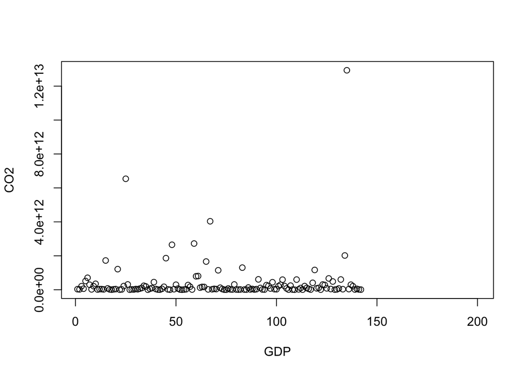

```
## integer(0)
```

```r
plot(gap2007_co2$gdp_tot, gap2007_co2$mtCO2, type="p", xlab="GDP", ylab="CO2")
identify(gap2007_co2$gdp_tot, gap2007_co2$mtCO2, labels=gap2007_co2$country)
```

You can click on the points to identify which countries are the outliers.

### Key Points

- Extracting text strings that match a pattern just like in bash using grep()
- Apply a function across a row and/or across a column and return the results
- data.frame - creates a data frame combining in column-wise fashion - keeps special info from data frames like factors
- aggregate - splits data into subsets, computes summary statistics for each subset and then returns the results
- split - splits data into a list. Useful if you plan to do many different applys on the same subsets of your data